# Bay Wheels' Trip Data Exploration and Visualization

## Investigation Overview

In this investigation, I wanted to look at the characteristics of bike trips that could be used to predict trip duration, trip time, and customer usage.

## Dataset Overview

This document explores a dataset containing [information](https://www.lyft.com/bikes/bay-wheels/system-data) about individual rides made in [Bay Wheels](https://en.wikipedia.org/wiki/Bay_Wheels)' bike-sharing system covering the greater San Francisco Bay area. The dataset is data from January 2019 and can be manually downloaded [here](https://s3.amazonaws.com/baywheels-data/index.html).

```python
#check if it converted properly
df_clean.info()
```

```
<class 'pandas.core.frame.DataFrame'>
Int64Index: 191834 entries, 0 to 192081
Data columns (total 14 columns):
duration_sec               191834 non-null int64
start_time                 191834 non-null datetime64[ns]
end_time                   191834 non-null datetime64[ns]
start_station_id           191834 non-null float64
start_station_name         191834 non-null object
start_station_latitude     191834 non-null float64
start_station_longitude    191834 non-null float64
end_station_id             191834 non-null float64
end_station_name           191834 non-null object
end_station_latitude       191834 non-null float64
end_station_longitude      191834 non-null float64
bike_id                    191834 non-null int64
user_type                  191834 non-null category
bike_share_for_all_trip    191834 non-null object
dtypes: category(1), datetime64[ns](2), float64(6), int64(2), object(3)
memory usage: 20.7+ MB
```

## Trip Count vs Trip Duration (min)

Trip durations in the dataset take on a very large range of values, from about 1 minute at the lowest, to about 23.3 hours at the highest. Zoomed in on 99% of the trips, the distribution of trip duration is skewed right. We can see that 99% of the trips were less than one hour in duration. Most the the trips fell between the 5 and 10 minute range.

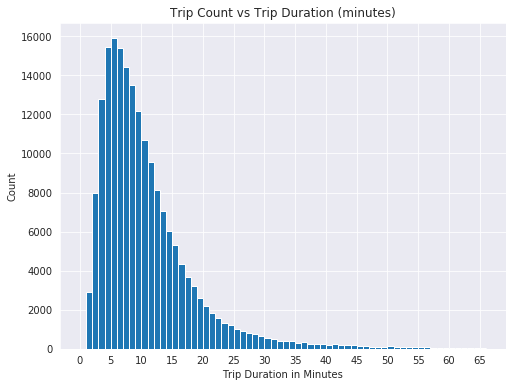

```python
# set the size of the plot
plt.figure(figsize = (8, 6))

# set the bin size and x tick size
bins = np.arange(0, 67, 1)
ticks = np.arange(0, 67 , 5)

# set the x ticks
plt.xticks(ticks, ticks)
# set the axis labels and title
plt.xlabel('Trip Duration in Minutes')
plt.ylabel('Count')
plt.title('Trip Count vs Trip Duration (minutes)')

# plot the data
plt.hist(data = df_clean, x = 'duration_min', bins = bins);
```

## Trip Count vs Day

We can see that Thursday has the most trips. We can also see that more trips happen during the weekdays. There are less trips happening during the weekend. Maybe the hour trips happen is causing this?

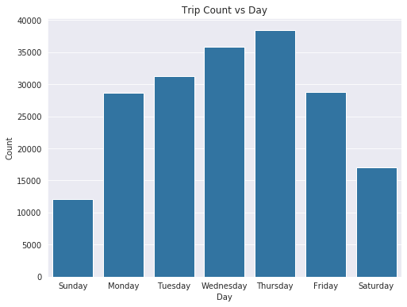

```python
# set the size of the plot
plt.figure(figsize = (8, 6))

# set colors in the plot
base_color = sns.color_palette()[0]

# this is the plot
ax = sns.countplot(data = df_clean, x = 'start_day', color = base_color)

# set axis labels and title
ax.set(xlabel = 'Day', ylabel = 'Count', title = 'Trip Count vs Day')

# show the plot
plt.show()
```

## Trip Count vs Hour

We can see two peaks in the data. The first peak is at 8 AM, and the second peak is at 5 PM. It is possible that those trips are users commuting to work. We can't say that for certain as we would need more personalized data, and we don't have that type of data since our dataset was anonymized to preserve privacy. Though if it is really because of work commute, it would be in line with the *Trip Count vs Day* plot earlier. Monday through Friday had more trips and those are the normal work days.

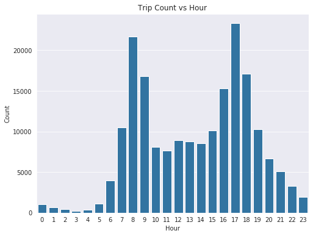

```python
# set the figure size
plt.figure(figsize = (8, 6))

# this is the plot
ax = sns.countplot(data = df_clean, x = 'start_hour', color = base_color)

# set axis labels and title
ax.set(xlabel = 'Hour', ylabel = 'Count', title = 'Trip Count vs Hour')

# show the plot
plt.show()
```

## Trip Count vs User Type

There are two types of user. Customers are users who are not members of the bike sharing service, while subscribers are. We can see that there are more subscribers than there are customers.

```
Subscriber    168561
Customer       23273
Name: user_type, dtype: int64
```

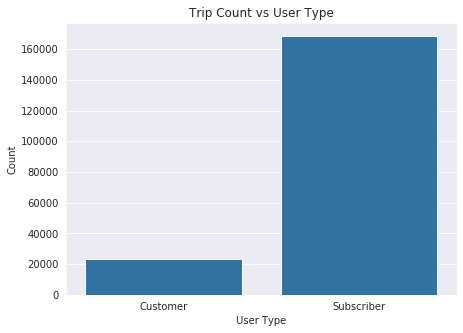

```python
# i'm just looking at the values for the two bars
print(df_clean['user_type'].value_counts())

# set the figure size
plt.figure(figsize = (7,5))

# this is the plot
ax = sns.countplot(data = df_clean, x = 'user_type', color = base_color)

# set labels and title
ax.set(xlabel = 'User Type', ylabel = 'Count', title = 'Trip Count vs User Type')

# show the plot
plt.show()
```

## Trip Count by Day and Hour

After looking at *Trip Count vs Day* and *Trip Count vs Hour* plots, it made me think about plotting the number of trips on each day and hour. The result is this plot. Please first notice that the y-axis for each histogram is not the same scale. This plot shows histograms for each day. Each day's trip count is distributed over the hour of the day. For each day, we can see which time periods have higher trip counts.

On Sundays and Saturdays, we can see that the trip count is highest between 2-3 PM. Mondays through Fridays, you can see two peaks. The first peak is at 8 AM and the second peak is at 5 PM. The two peak times match the two peak times in *Trip Count vs Hour*. If it is not obvious, Mondays - Fridays have higher trip counts than Saturdays and Sundays. The earlier *Trip Count vs Day* plot would support that.

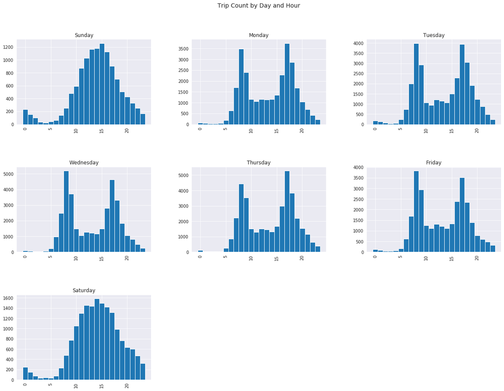

```python
# plot figure size
plt.rcParams["figure.figsize"] = [20,15]
# bins to make the tick numbers centered
bins24 = np.arange(25) - 0.5
# the plot
df_clean.hist(column = 'start_hour', by = 'start_day', bins = bins24)
plt.suptitle('Trip Count by Day and Hour', fontsize = 14);
```

## Trip Count by Hour and User Type

Customers' trip count first peaks at 8 AM and peaks again at 5 PM. Subscribers' trip count first peaks at 8 AM and peaks again at 5 PM. The difference between the two user types is the scale of the plots. The Customer and Subscriber hours may peak at the same time, but you can see that there is a huge difference in the distribution of trip counts.

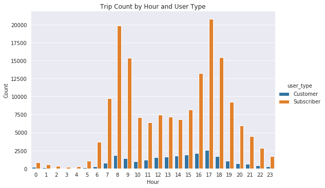

```python
# the plot
sns.catplot(data = df_clean, x = 'start_hour', kind = 'count', hue = 'user_type', height = 5, aspect = 1.5)
# labels
plt.title('Trip Count by Hour and User Type')
plt.xlabel('Hour')
plt.ylabel('Count');
```

## Trip Count by Day and User Type

The plot shows us the trip count broken down by day of the week and user type. For subscribers their highest trip counts are on Thursdays, while the customers highest trip counts are on Saturdays.

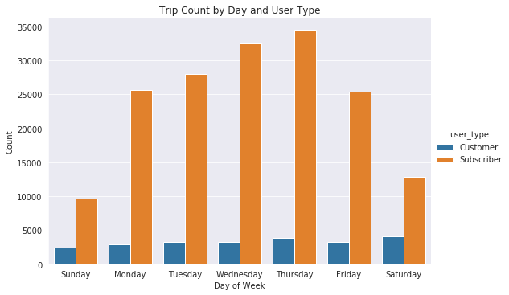

```python
# the plot
sns.catplot(data = df_clean, x = 'start_day', kind = 'count', hue = 'user_type', height = 5, aspect = 1.5)
# labels
plt.title('Trip Count by Day and User Type')
plt.xlabel('Day of Week')
plt.ylabel('Count');
```

## Average Trip Duration by Day and User Type

Subscribers have much shorter trips than customers on each day. Both user types have an increased trip duration on the weekends compared to the weekdays. Subscribers have a consistent average trip duration during the weekdays.

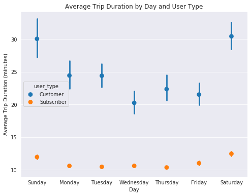

```python
# the plot
sns.pointplot(data = df_clean, x = 'start_day', y = 'duration_min', hue = 'user_type', linestyles = '')
# labels
plt.xlabel('Day')
plt.ylabel('Average Trip Duration (minutes)')
plt.title('Average Trip Duration by Day and User Type');
```

The heatmaps show that customers use the bikeshare service heavily on the weekends. Customers use the service the most on Saturdays at 2 PM. They also use the service a lot on Thursday at 5 PM. Subscribers use the service mostly during the weekdays at 8 AM and 5 PM.

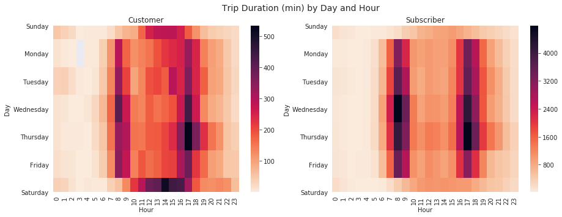

```python
# figure size
plt.figure(figsize = (15,5))
# plot location
plt.subplot(1,2,1)
# separating customers and subscibers to different dataframes
cus = df_clean.query('user_type == "Customer"')
cus_counts = cus.groupby(['start_day', 'start_hour']).size()
cus_counts = cus_counts.reset_index(name = 'count')
cus_counts = cus_counts.pivot(index = 'start_day', columns = 'start_hour', values = 'count')
# the plot
sns.heatmap(cus_counts, cmap = 'rocket_r')
# labels
plt.title('Customer')
plt.xlabel('Hour')
plt.ylabel('Day');

plt.subplot(1,2,2)
sub = df_clean.query('user_type == "Subscriber"')
sub_counts = sub.groupby(['start_day', 'start_hour']).size()
sub_counts = sub_counts.reset_index(name = 'count')
sub_counts = sub_counts.pivot(index = 'start_day', columns = 'start_hour', values = 'count')
sns.heatmap(sub_counts, cmap = 'rocket_r')
plt.title('Subscriber')
plt.xlabel('Hour')
plt.ylabel('Day')
plt.suptitle('Trip Duration (min) by Day and Hour', fontsize = 14);
```